# Structural Divergence Analysis

Maria Laura Marcos, Julian Echave

# Introduction

We study the evolutionary divergence of proteins using the LF-ENM and comparing simulated mutants with experimental data.

We studied the sh3 family. We used the ENM ANM with R0 = 12.5 to generate mutants. We used as reference for the ENM the protein with pdb code 1lcka. We simulated 10 mutants of this reference for each protein of the family. The sh3 family is of the type small beta and consists of the following proteins:

```
 [1] "1shg"   "1shfa"  "2src"   "1qcfa"  "1qlya"  "1bbza"  "1gria1"
 [8] "1gbra"  "1cska"  "1ckaa"  "1sema"  "1gria2" "1ycsb"  "2hsp"
[15] "1ark"   "1aoja"  "1pht"   "1bb9"   "1awj"
```

### Structural divergence along normal modes

In this section we consider structural divergence using normal mode coordinates. Pn is the square divergence along a normal mode relative to the mean.

### Pn vs. mode energy

Note: lines are the median, 0.05 and 0.95 quantiles fit using rq(Pn ~ sn2). sn2 = 1/energy is the expected MSD of along mode n. The mean value of Pn should be a linear function of sn2 (Pn is normalized, sn2 is not).

Here we show the square deviation along each normal mode (normalized so that = 1) vs. the normal-mode’s energy. For the empirical data, we use the actual energy obtained from Keff for the given comparison. It is this energy the one that should be used, since it’s inverse is the expected value of Pn. Lines are the .5 (median), .05, and .95 quantiles obtained using rq()

Upper panel: simulated vs empirical data, shown separately. Lower panel: simulated vs empirical overlaped and zoomed to better see the pattern.

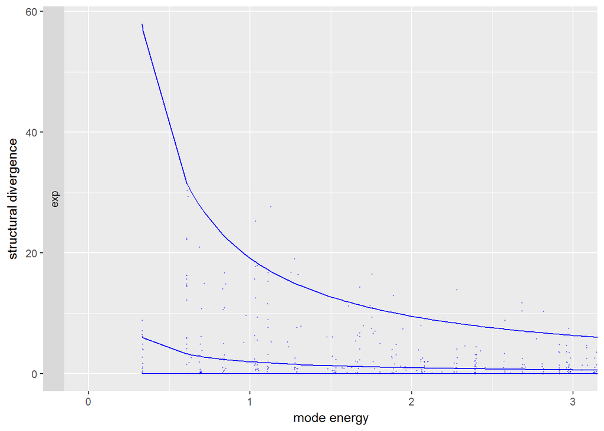

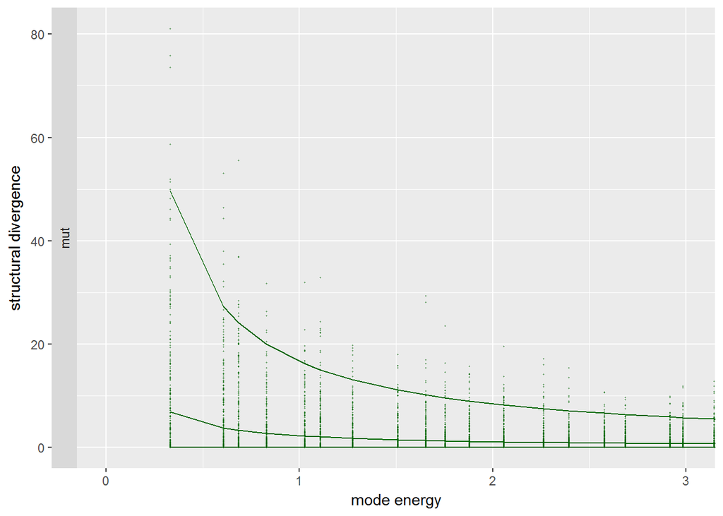

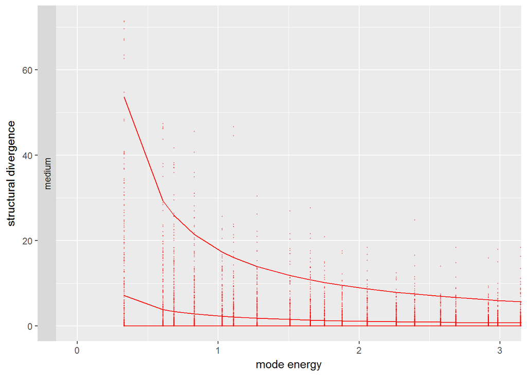

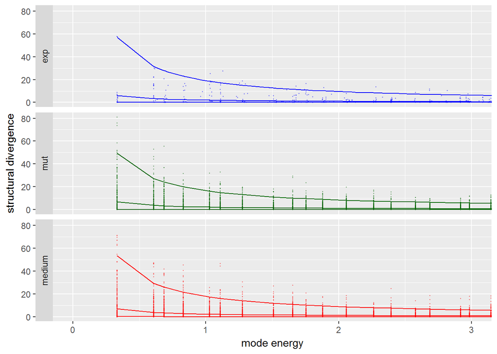

### median(Pn) vs mode energy

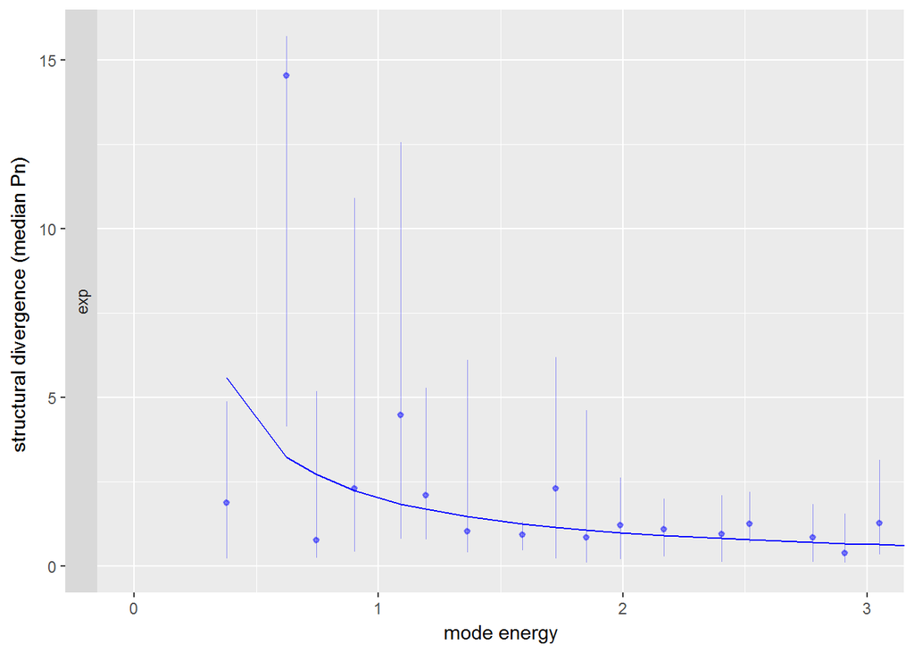

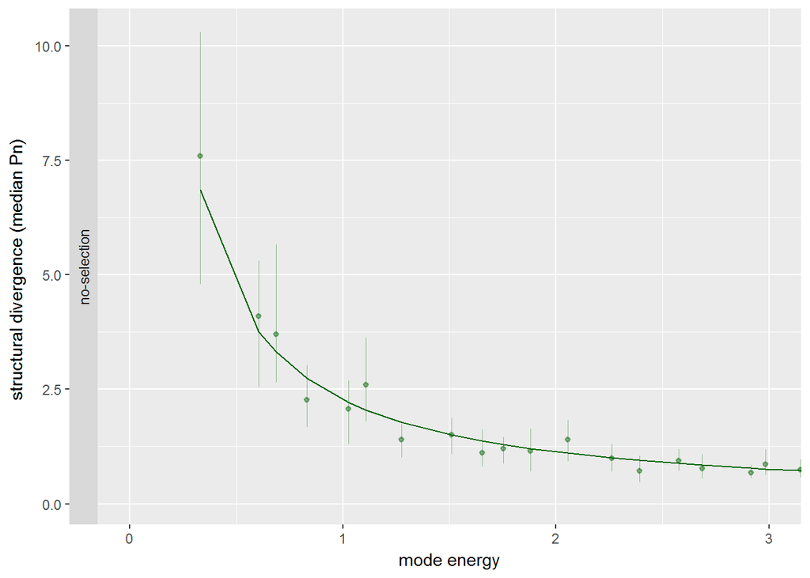

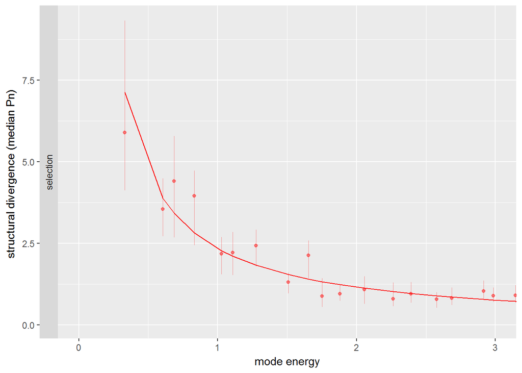

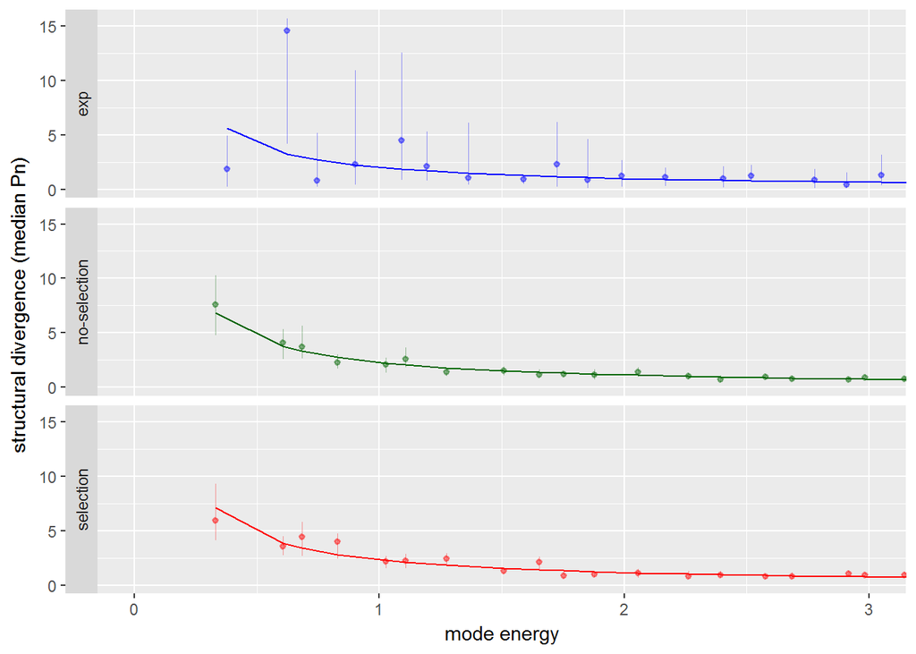

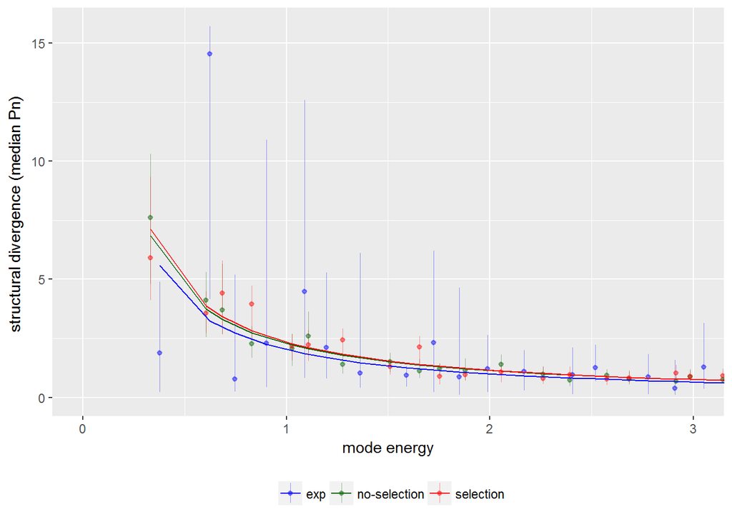

### correlaction between mode profiles

(calculated for the first 100 modes)

| comparison | R |
| --- | --- |
| exp vs mut | 0.54 |
| exp vs medium | 0.53 |
| mut vs medium | 0.94 |

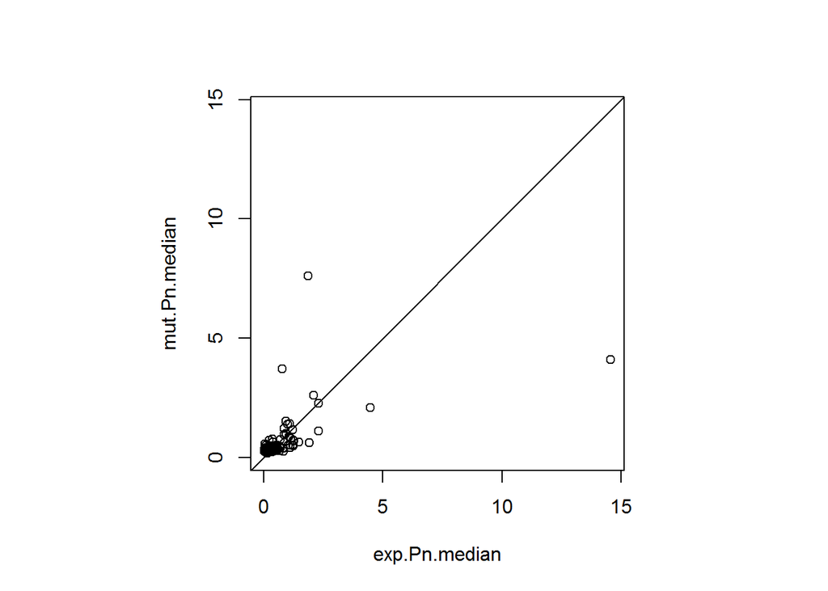

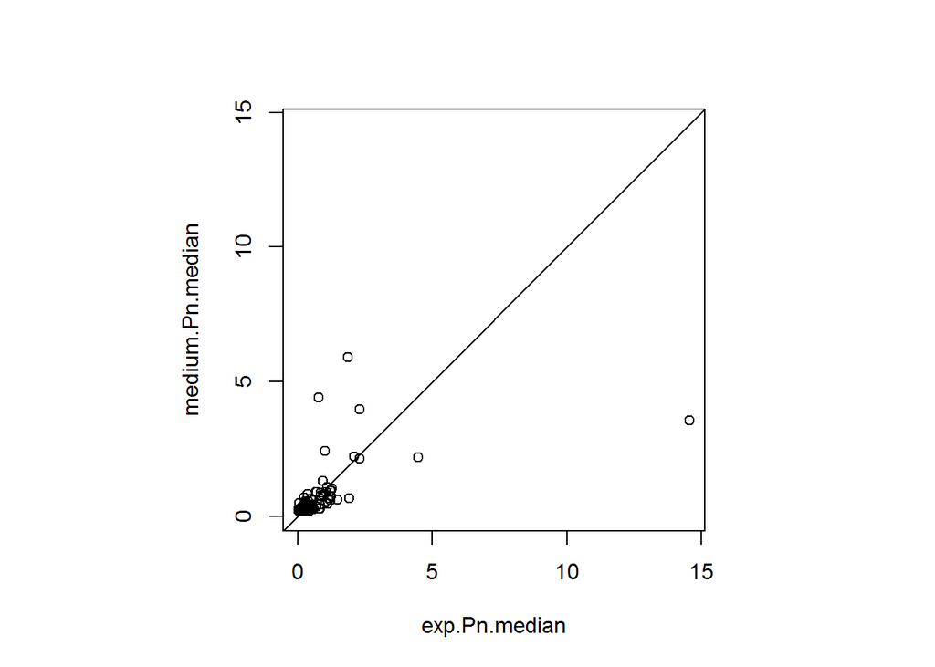

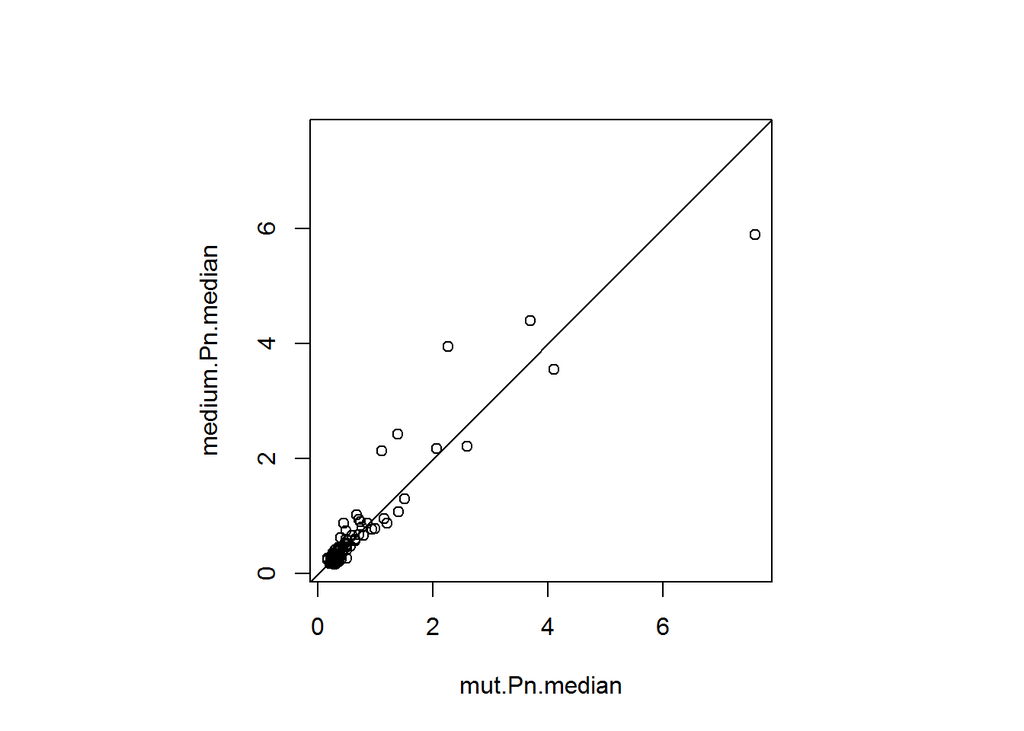